# IODS course project

Andrei Kudinov

# Introduction to Open Data Science - Course Project

# Chapter 1. About the project.

I have high expectations for this course. I want to learn data stat and visualization tools. I would like to learn and start routine use of Markdown. I am using simple build-in functions to manipulate data during my working process, but functions and etc. not often used. First workshop was nice, same as guidelines how to install soft. I could not solve issue with my Valti computer, so I am using home MAC. Could Markdown actually check spelling? Do you know? My GitHub is https://github.com/ZoomMan91/IODS-project

```r
# This is a so-called "R chunk" where you can write R code.

date()
```

```
## [1] "Thu Nov 19 23:00:12 2020"
```

```r
today<-Sys.Date()
print("Do we need code here?")
```

```
## [1] "Do we need code here?"
```

```r
print("what is date?")
```

```
## [1] "what is date?"
```

```r
print("Is it?")
```

```
## [1] "Is it?"
```

```r
today
```

```
## [1] "2020-11-19"
```

The text continues here.

# Chapter 2. Regression and model validation.

Today is:

```r
date()
```

```
## [1] "Thu Nov 19 23:00:12 2020"
```

#### Task 1. Read and explore the data.

Reading data from local directory.

```r
students2014<-read.table(file="data/learning2014.txt",header=T, sep="\t")
```

Success! Let’s check the data structure using **R** functions **dim** and **str**.

```r
dim(students2014)
```

```
## [1] 166   7
```

```r
str(students2014)
```

```
## 'data.frame':    166 obs. of  7 variables:
##  $ gender  : chr  "F" "M" "F" "M" ...
##  $ Age     : int  53 55 49 53 49 38 50 37 37 42 ...
##  $ Attitude: int  37 31 25 35 37 38 35 29 38 21 ...
##  $ deep    : num  3.58 2.92 3.5 3.5 3.67 ...
##  $ stra    : num  3.38 2.75 3.62 3.12 3.62 ...
##  $ surf    : num  2.58 3.17 2.25 2.25 2.83 ...
##  $ Points  : int  25 12 24 10 22 21 21 31 24 26 ...
```

The data has 7 variables from 166 students. Variables **deep**, **strategic** and **surface** learning were created based on survey done in 2014. Method to calculate variables is described [here](https://www.mv.helsinki.fi/home/kvehkala/JYTmooc/JYTOPKYS2-meta.txt). Rest variables are **gender**, **Age**, global **Attitude** towards statistics, and final exam **Points**.

#### Task 2. Graphcal overview of the data.

Inbuild **R** function **plot** quite ugly. Therefore I would use [ggplot2](https://ggplot2.tidyverse.org/reference/ggplot.html) as much elegant way to overview the data.

Let’s access ggplot package first.

```r
library(ggplot2)
```

[GGally](https://ggobi.github.io/ggally/) package will be useful also.

```r
library(GGally)
```

Now let’s create pairwise plot presenting relationships among variables.

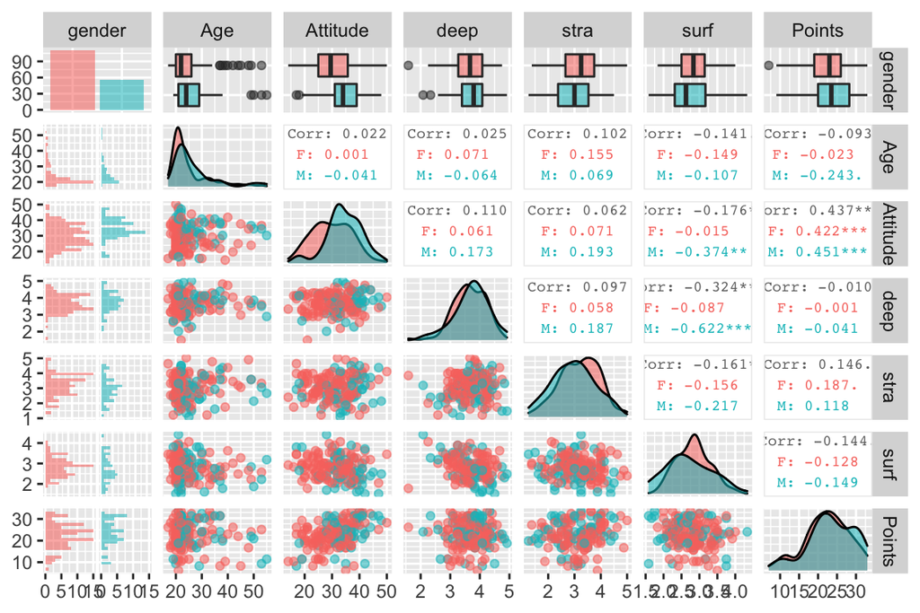

```r
ggpairs(students2014, mapping = aes(col=gender,alpha=0.3), lower = list(combo = wrap("facethist", bins = 20)),upper = list(continuous = wrap("cor", size = 2.5)))
```

summary of the data

```r
summary(students2014)
```

```
##     gender               Age           Attitude          deep
##  Length:166         Min.   :17.00   Min.   :14.00   Min.   :1.583
##  Class :character   1st Qu.:21.00   1st Qu.:26.00   1st Qu.:3.333
##  Mode  :character   Median :22.00   Median :32.00   Median :3.667
##                     Mean   :25.51   Mean   :31.43   Mean   :3.680
##                     3rd Qu.:27.00   3rd Qu.:37.00   3rd Qu.:4.083
##                     Max.   :55.00   Max.   :50.00   Max.   :4.917
##       stra            surf           Points
##  Min.   :1.250   Min.   :1.583   Min.   : 7.00
##  1st Qu.:2.625   1st Qu.:2.417   1st Qu.:19.00
##  Median :3.188   Median :2.833   Median :23.00
##  Mean   :3.121   Mean   :2.787   Mean   :22.72
##  3rd Qu.:3.625   3rd Qu.:3.167   3rd Qu.:27.75
##  Max.   :5.000   Max.   :4.333   Max.   :33.00
```

Number of Female students in the data was larger then Males. The mean students age was 25.51 and the oldest student - 55 years old. Worth to check standard deviation.

```r
sd(students2014$Age)
```

```
## [1] 7.766078
```

The maximum earned exam point was 33, all student’s average was 22.72. According to ggpairs plot, most of the variables have normal distribution. The students attitude highly correlated with Exam points. No dependency was found between points and gender or age.  
The negative correlation with exam points was observed in deep and surf variables. In opposite strategic learning positively correlated with exam points. Let’s build linear model…

#### Task 3. Linear model.

Explanatory variables I choose in a first run were attitude, deep, strategic and surface leanings.

The model had look:

```r
model=lm(Points~Attitude+stra+deep+surf, students2014)
summary(model)
```

```
##
## Call:
## lm(formula = Points ~ Attitude + stra + deep + surf, data = students2014)
##
## Residuals:
##      Min       1Q   Median       3Q      Max
## -16.7335  -3.1992   0.7975   3.4002  11.6582
##
## Coefficients:
##             Estimate Std. Error t value Pr(>|t|)
## (Intercept) 15.39999    5.02450   3.065  0.00255 **
## Attitude     0.34362    0.05739   5.987 1.34e-08 ***
## stra         0.88475    0.54110   1.635  0.10398
## deep        -1.00721    0.78702  -1.280  0.20247
## surf        -0.91045    0.83901  -1.085  0.27948
## ---
## Signif. codes:  0 '***' 0.001 '**' 0.01 '*' 0.05 '.' 0.1 ' ' 1
##
## Residual standard error: 5.286 on 161 degrees of freedom
## Multiple R-squared:  0.2154, Adjusted R-squared:  0.1959
## F-statistic: 11.05 on 4 and 161 DF,  p-value: 6.057e-08
```

Only Attitude here pass significance test in this model. The value 1.34e-08 *** in Pr(>|t|) column.

I have tried different models and find out that only Attitude has a significant relationship with exam points.

Perfect model is:

```r
perfect_model<-lm(Points~Attitude, students2014)
summary(perfect_model)
```

```
##
## Call:
## lm(formula = Points ~ Attitude, data = students2014)
##
## Residuals:
##      Min       1Q   Median       3Q      Max
## -16.9763  -3.2119   0.4339   4.1534  10.6645
##
## Coefficients:
##             Estimate Std. Error t value Pr(>|t|)
## (Intercept) 11.63715    1.83035   6.358 1.95e-09 ***
## Attitude     0.35255    0.05674   6.214 4.12e-09 ***
## ---
## Signif. codes:  0 '***' 0.001 '**' 0.01 '*' 0.05 '.' 0.1 ' ' 1
##
## Residual standard error: 5.32 on 164 degrees of freedom
## Multiple R-squared:  0.1906, Adjusted R-squared:  0.1856
## F-statistic: 38.61 on 1 and 164 DF,  p-value: 4.119e-09
```

#### Task 4. Explain the summary.

Residuals are not symmetrically distributed. Alpha parameter is 11.63 Effect of attitude on examine point is 0.352 with standard error 0.056. P test was 4^10-9, which shows significant relationship between target and explanatory variables. Roughly 19% examine Points variance was explained by Attitude variable, according to R2.

#### Task 5. Diagnostic plots.

Let’s create diagnostic plots.

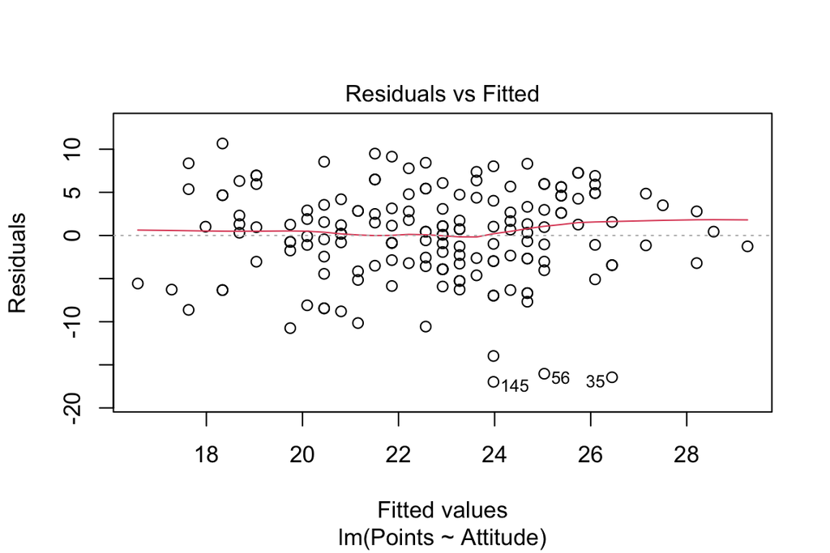

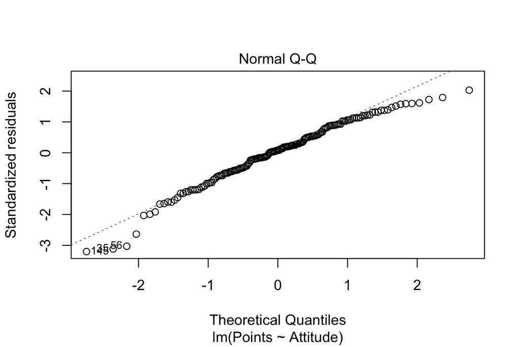

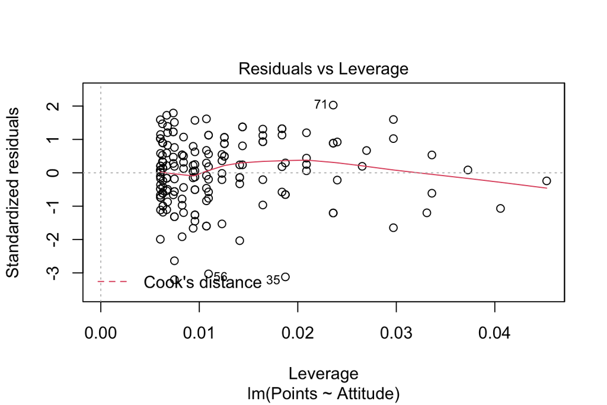

```r
plot(perfect_model,which=c(1,2,5))
```

Scatter plot of Residual vs Fitted values presenting random spread of points. This means that variance has constant variance. No abnormall pattern was detected.

Normality Q-Q plot presenting distribution of model errors. Slight deviation is seen at the beginning and the end of the line. But generally speaking errors are normally distributed as they following line.

Residuals vs Leverage plot showing absence of outspending observations in the linear model.

All three plots are supporting model linearity assumption and normal distribution of errors.

# Chapter 3. Logistic regression

Today is:

```
## [1] "Thu Nov 19 23:00:23 2020"
```

#### Task 1. If you see this, hence task 1 is done.

#### Task 2. Read and explore the data.

I made my own data set, but mess provided by course organizers made me fill uncomfortable to use it. I did not get clear answer [here](https://mooc.helsinki.fi/mod/forum/discuss.php?d=21108#p50025), so I will use provided by Reijo Sund data code. At least points are not interesting for me anymore. Feel free to cut them down =D

Reading the data.

```r
alc <- read.csv("https://github.com/rsund/IODS-project/raw/master/data/alc.csv")
```

The data derived from [public UCI repository](https://archive.ics.uci.edu/ml/datasets/Student+Performance). The data approach student achievement in secondary education measured in two Portuguese schools. Students performance was measured in to classes: Portuguese language and Math. Additional to personal information and Grades data has information about alcohol consumption of students. Data has no personal data and was merged using set of columns. Duplicated “unique” columns were deleted.

Data dimension:

```
## [1] 370  51
```

```
##   school sex age address famsize Pstatus Medu Fedu     Mjob     Fjob     reason
## 1     GP   F  15       R     GT3       T    1    1  at_home    other       home
## 2     GP   F  15       R     GT3       T    1    1    other    other reputation
## 3     GP   F  15       R     GT3       T    2    2  at_home    other reputation
## 4     GP   F  15       R     GT3       T    2    4 services   health     course
## 5     GP   F  15       R     GT3       T    3    3 services services reputation
## 6     GP   F  15       R     GT3       T    3    4 services   health     course
##   guardian traveltime studytime schoolsup famsup activities nursery higher
## 1   mother          2         4       yes    yes        yes     yes    yes
## 2   mother          1         2       yes    yes         no      no    yes
## 3   mother          1         1       yes    yes        yes     yes    yes
## 4   mother          1         3       yes    yes        yes     yes    yes
## 5    other          2         3        no    yes        yes     yes    yes
## 6   mother          1         3       yes    yes        yes     yes    yes
##   internet romantic famrel freetime goout Dalc Walc health n id.p id.m failures
```

[output cut: 20 more lines]

#### Task 3. Choose and hypothesize variables.

From variables above I will choose: 1) famrel 2) activities 3) address 4) higher Let’s put ideas on the paperer now. **1)famrel** - quality of family relationships. This is trivial and common to blame family. So why not to do as STM wants. We always assume that bad climate could cause problems with alcohol and drugs. But, I don’t think bad family climate has negative impact. **2)activities** - extra-curricular activities. I suppose that busy or interested person has less time and willing to consume alcohol. At least no time to be drunk. Thus, less consumption. Need to check. **3)address** - type of home address. The stereotype will be that people from rural area drinking more. I think oposite youngsters in urban area have more ability to get and drink alcohol. Let’s check that out. **4)higher** - wants to take higher education This is obvious. Person interested in self-development potentially has less time and willing to drink.

#### Task 4. Explore the data.

```r
choosen<-c("famrel","activities","address","higher","high_use","alc_use")
my_alc<-select(alc,(one_of(choosen)))
my_alc %>% group_by(famrel,high_use) %>% summarise(count = n())
```

```
## # A tibble: 10 x 3
## # Groups:   famrel [5]
##    famrel high_use count
##     <int> <lgl>    <int>
##  1      1 FALSE        6
##  2      1 TRUE         2
##  3      2 FALSE        9
##  4      2 TRUE         9
##  5      3 FALSE       39
##  6      3 TRUE        25
##  7      4 FALSE      128
##  8      4 TRUE        52
##  9      5 FALSE       77
## 10      5 TRUE        23
```

Most of students are from families with good (4) and perfect (5) relationships. Percent of drinkers is higher in good familiear compare to perfect ones. Close to equal in families with rating 2 and 3.

```r
my_alc %>% group_by(address,high_use) %>% summarise(count = n())
```

```
## # A tibble: 4 x 3
## # Groups:   address [2]
##   address high_use count
##   <chr>   <lgl>    <int>
## 1 R       FALSE       50
## 2 R       TRUE        31
## 3 U       FALSE      209
## 4 U       TRUE        80
```

I would rather say that percent of student in rural area (38%) is higher than in Urban (28%).

```r
my_alc %>% group_by(activities,high_use) %>% summarise(count = n())
```

```
## # A tibble: 4 x 3
## # Groups:   activities [2]
##   activities high_use count
##   <chr>      <lgl>    <int>
## 1 no         FALSE      120
## 2 no         TRUE        59
## 3 yes        FALSE      139
## 4 yes        TRUE        52
```

Looks like same amount of students consuming a lot of alcohol in no and yes cases. In other words activities has no impact.

```r
my_alc %>% group_by(higher,high_use) %>% summarise(count = n())
```

```
## # A tibble: 4 x 3
## # Groups:   higher [2]
##   higher high_use count
##   <chr>  <lgl>    <int>
## 1 no     FALSE        7
## 2 no     TRUE         9
## 3 yes    FALSE      252
## 4 yes    TRUE       102
```

Let’s see the distribution (bar) plots.

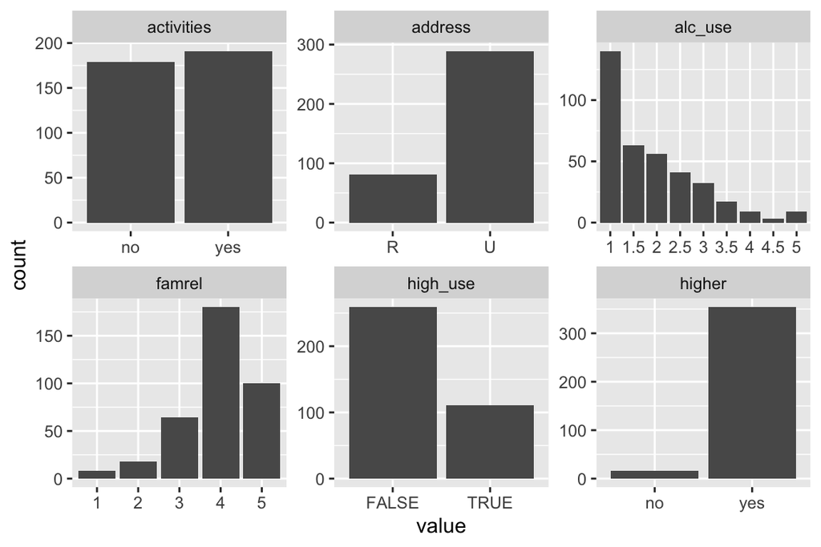

```r
gather(my_alc) %>% ggplot(aes(value)) + facet_wrap("key", scales = "free")+geom_bar()
```

#### Task 5. LOGistic regression.

First let’s fit logistic regression model and print summary.

```r
model<- glm(high_use ~ address+activities+ famrel+higher-1, data = my_alc, family = "binomial")
summary(model)
```

```
##
## Call:
## glm(formula = high_use ~ address + activities + famrel + higher -
##     1, family = "binomial", data = my_alc)
##
## Deviance Residuals:
##     Min       1Q   Median       3Q      Max
## -1.4563  -0.8169  -0.7402   1.3058   1.8123
##
## Coefficients:
##               Estimate Std. Error z value Pr(>|z|)
## addressR        1.6812     0.7225   2.327   0.0200 *
## addressU        1.2019     0.7005   1.716   0.0862 .
## activitiesyes  -0.2286     0.2342  -0.976   0.3291
## famrel         -0.2724     0.1239  -2.199   0.0279 *
## higheryes      -1.0383     0.5260  -1.974   0.0484 *
## ---
## Signif. codes:  0 '***' 0.001 '**' 0.01 '*' 0.05 '.' 0.1 ' ' 1
##
## (Dispersion parameter for binomial family taken to be 1)
##
##     Null deviance: 512.93  on 370  degrees of freedom
## Residual deviance: 438.13  on 365  degrees of freedom
## AIC: 448.13
##
## Number of Fisher Scoring iterations: 4
```

I added -1 to see effect of Rural address instead of Intercept. From model we could see that Rural address has statistical relationship with alcohol consumption. Both Rural and Urban areas has positive coefficient, but it is smaller in Urban area. Family relationship and want to have higher education variable’s also have statistical link and negative coefficient.

I don’t understand why I could not see activitiesno and higherno variables in table. But, if one would crate model with activities only, he/she well get sudden significance which was not the case before. I can show:

```r
idiotic_model<-glm(formula = high_use ~ activities - 1, family = "binomial", data = my_alc)
summary(idiotic_model)
```

```
##
## Call:
## glm(formula = high_use ~ activities - 1, family = "binomial",
##     data = my_alc)
##
## Deviance Residuals:
##     Min       1Q   Median       3Q      Max
## -0.8943  -0.8943  -0.7972   1.4899   1.6131
##
## Coefficients:
##               Estimate Std. Error z value Pr(>|z|)
## activitiesno   -0.7100     0.1590  -4.465 8.01e-06 ***
## activitiesyes  -0.9832     0.1626  -6.049 1.46e-09 ***
## ---
## Signif. codes:  0 '***' 0.001 '**' 0.01 '*' 0.05 '.' 0.1 ' ' 1
##
## (Dispersion parameter for binomial family taken to be 1)
##
##     Null deviance: 512.93  on 370  degrees of freedom
## Residual deviance: 450.59  on 368  degrees of freedom
## AIC: 454.59
##
## Number of Fisher Scoring iterations: 4
```

Make odds ratio.

```r
OR <- coef(model) %>% exp
CI<-confint(model)%>%exp
cbind(OR, CI)
```

```
##                      OR     2.5 %     97.5 %
## addressR      5.3717313 1.3171301 22.8034908
## addressU      3.3264809 0.8481833 13.4937683
## activitiesyes 0.7956502 0.5019263  1.2592797
## famrel        0.7615264 0.5964673  0.9712265
## higheryes     0.3540559 0.1216519  0.9916501
```

I will read this [material](https://www.ncbi.nlm.nih.gov/pmc/articles/PMC5253299/), but not yet. Course information is limited and I did not get how to interpret table above.

#### Task 6. Prediction.

Let’s fit the prediction model similar to presented in DataCamp

```r
probabilities <- predict(model, type = "response")
my_alc <- mutate(my_alc, probability = probabilities)
my_alc <- mutate(my_alc, prediction = (probability > 0.5))
table(high_use = my_alc$high_use, prediction = my_alc$prediction)
```

```
##         prediction
## high_use FALSE TRUE
##    FALSE   253    6
##    TRUE    101   10
```

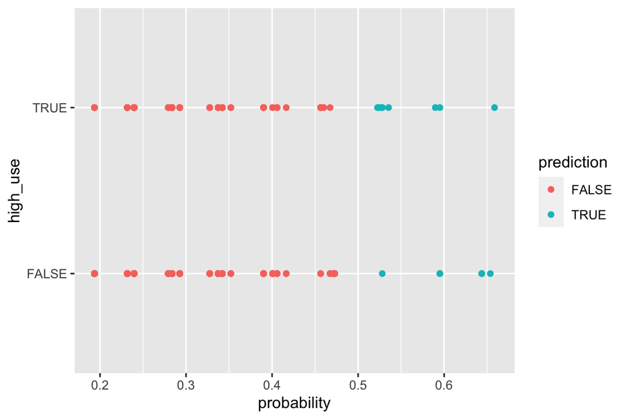

```r
g3 <- ggplot(my_alc, aes(x = probability, y = high_use,col=prediction))
g3+geom_point()
```

```r
loss_func <- function(class, prob) {
  n_wrong <- abs(class - prob) > 0.5
  mean(n_wrong)
}

loss_func(class = my_alc$high_use, prob = my_alc$probability)
```

```
## [1] 0.2891892
```

I will not perform task 7 and 8, just will say that we actively using modified cross-validation while choosing model to predict breeding values of farm animals in our customer projects. It is working and needed.

# Chapter 4. Clustering and classification.

Today is:

```
## [1] "Thu Nov 19 23:00:27 2020"
```

#### Task 1. Create chapter4.Rmd => Done!

#### Task 2. Load Boston data.

Way to read data same as in DataCamp.

```r
library(MASS)
data("Boston")
```

Boston data is public data from MASS package including various data sets. Data was originally presented in 1978. The Boston Housing Dataset consists of price of houses in various places in Boston. Alongside with price, the dataset also provide information such as Crime (CRIM), areas of non-retail business in the town (INDUS), the age of people who own the house (AGE). Detailed information and links to original publications are presented [here](https://stat.ethz.ch/R-manual/R-devel/library/MASS/html/Boston.html).

Let’s check structure and dimensions.

```r
dim(Boston)
```

```
## [1] 506  14
```

```r
str(Boston)
```

```
## 'data.frame':    506 obs. of  14 variables:
##  $ crim   : num  0.00632 0.02731 0.02729 0.03237 0.06905 ...
##  $ zn     : num  18 0 0 0 0 0 12.5 12.5 12.5 12.5 ...
##  $ indus  : num  2.31 7.07 7.07 2.18 2.18 2.18 7.87 7.87 7.87 7.87 ...
##  $ chas   : int  0 0 0 0 0 0 0 0 0 0 ...
##  $ nox    : num  0.538 0.469 0.469 0.458 0.458 0.458 0.524 0.524 0.524 0.524 ...
##  $ rm     : num  6.58 6.42 7.18 7 7.15 ...
##  $ age    : num  65.2 78.9 61.1 45.8 54.2 58.7 66.6 96.1 100 85.9 ...
##  $ dis    : num  4.09 4.97 4.97 6.06 6.06 ...
##  $ rad    : int  1 2 2 3 3 3 5 5 5 5 ...
##  $ tax    : num  296 242 242 222 222 222 311 311 311 311 ...
##  $ ptratio: num  15.3 17.8 17.8 18.7 18.7 18.7 15.2 15.2 15.2 15.2 ...
##  $ black  : num  397 397 393 395 397 ...
##  $ lstat  : num  4.98 9.14 4.03 2.94 5.33 ...
##  $ medv   : num  24 21.6 34.7 33.4 36.2 28.7 22.9 27.1 16.5 18.9 ...
```

So, data has 506 observations and 14 variables. Most of the variables are numerical, except dummy variable chas and rad variable - index of accessibility to radial highways.

#### Task 3. Graphical overvie of the data.

Let’s do graphical overview of the data. I tryed ggpairs but too much data. Than let’s use example from DataCamp. Correlation using cycles.

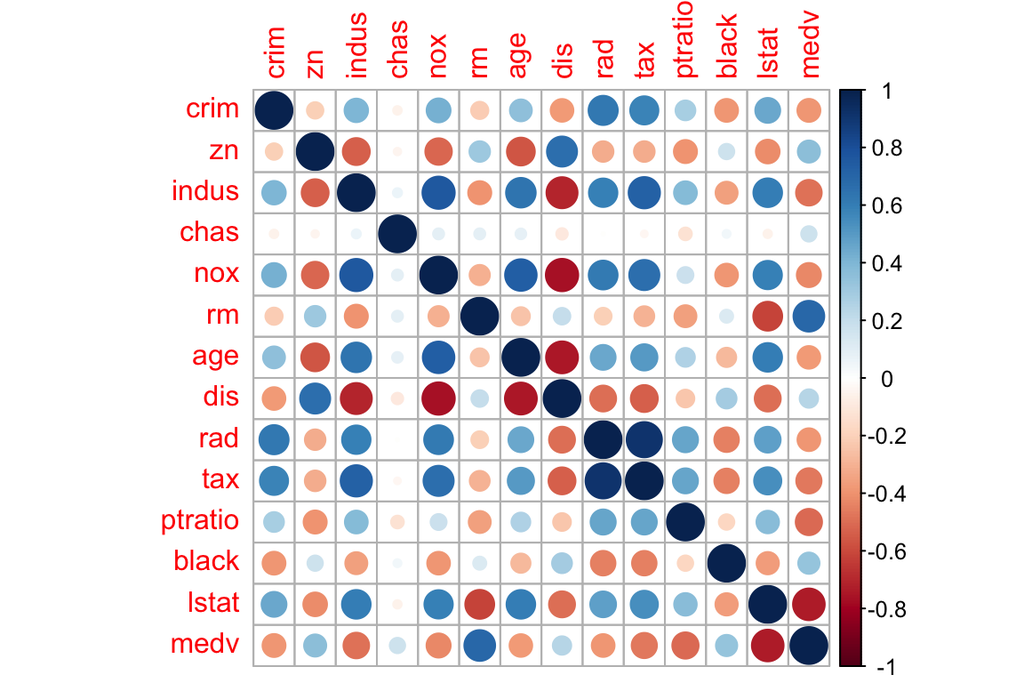

```r
cor_matrix<-cor(Boston)
corrplot(cor_matrix, method="circle")
```

Now, let’s print out summary.

```r
summary(Boston)
```

```
##       crim                zn             indus            chas
##  Min.   : 0.00632   Min.   :  0.00   Min.   : 0.46   Min.   :0.00000
##  1st Qu.: 0.08205   1st Qu.:  0.00   1st Qu.: 5.19   1st Qu.:0.00000
##  Median : 0.25651   Median :  0.00   Median : 9.69   Median :0.00000
##  Mean   : 3.61352   Mean   : 11.36   Mean   :11.14   Mean   :0.06917
##  3rd Qu.: 3.67708   3rd Qu.: 12.50   3rd Qu.:18.10   3rd Qu.:0.00000
##  Max.   :88.97620   Max.   :100.00   Max.   :27.74   Max.   :1.00000
##       nox               rm             age              dis
##  Min.   :0.3850   Min.   :3.561   Min.   :  2.90   Min.   : 1.130
##  1st Qu.:0.4490   1st Qu.:5.886   1st Qu.: 45.02   1st Qu.: 2.100
##  Median :0.5380   Median :6.208   Median : 77.50   Median : 3.207
##  Mean   :0.5547   Mean   :6.285   Mean   : 68.57   Mean   : 3.795
##  3rd Qu.:0.6240   3rd Qu.:6.623   3rd Qu.: 94.08   3rd Qu.: 5.188
##  Max.   :0.8710   Max.   :8.780   Max.   :100.00   Max.   :12.127
##       rad              tax           ptratio          black
##  Min.   : 1.000   Min.   :187.0   Min.   :12.60   Min.   :  0.32
##  1st Qu.: 4.000   1st Qu.:279.0   1st Qu.:17.40   1st Qu.:375.38
##  Median : 5.000   Median :330.0   Median :19.05   Median :391.44
##  Mean   : 9.549   Mean   :408.2   Mean   :18.46   Mean   :356.67
##  3rd Qu.:24.000   3rd Qu.:666.0   3rd Qu.:20.20   3rd Qu.:396.23
##  Max.   :24.000   Max.   :711.0   Max.   :22.00   Max.   :396.90
##      lstat            medv
##  Min.   : 1.73   Min.   : 5.00
##  1st Qu.: 6.95   1st Qu.:17.02
##  Median :11.36   Median :21.20
##  Mean   :12.65   Mean   :22.53
##  3rd Qu.:16.95   3rd Qu.:25.00
##  Max.   :37.97   Max.   :50.00
```

```r
bo_sc<-scale(Boston)
bo_sc<-as.data.frame(bo_sc)
summary(bo_sc)
```

```
##       crim                 zn               indus              chas
##  Min.   :-0.419367   Min.   :-0.48724   Min.   :-1.5563   Min.   :-0.2723
##  1st Qu.:-0.410563   1st Qu.:-0.48724   1st Qu.:-0.8668   1st Qu.:-0.2723
##  Median :-0.390280   Median :-0.48724   Median :-0.2109   Median :-0.2723
##  Mean   : 0.000000   Mean   : 0.00000   Mean   : 0.0000   Mean   : 0.0000
##  3rd Qu.: 0.007389   3rd Qu.: 0.04872   3rd Qu.: 1.0150   3rd Qu.:-0.2723
##  Max.   : 9.924110   Max.   : 3.80047   Max.   : 2.4202   Max.   : 3.6648
##       nox                rm               age               dis
##  Min.   :-1.4644   Min.   :-3.8764   Min.   :-2.3331   Min.   :-1.2658
##  1st Qu.:-0.9121   1st Qu.:-0.5681   1st Qu.:-0.8366   1st Qu.:-0.8049
##  Median :-0.1441   Median :-0.1084   Median : 0.3171   Median :-0.2790
##  Mean   : 0.0000   Mean   : 0.0000   Mean   : 0.0000   Mean   : 0.0000
##  3rd Qu.: 0.5981   3rd Qu.: 0.4823   3rd Qu.: 0.9059   3rd Qu.: 0.6617
##  Max.   : 2.7296   Max.   : 3.5515   Max.   : 1.1164   Max.   : 3.9566
##       rad               tax             ptratio            black
##  Min.   :-0.9819   Min.   :-1.3127   Min.   :-2.7047   Min.   :-3.9033
##  1st Qu.:-0.6373   1st Qu.:-0.7668   1st Qu.:-0.4876   1st Qu.: 0.2049
##  Median :-0.5225   Median :-0.4642   Median : 0.2746   Median : 0.3808
##  Mean   : 0.0000   Mean   : 0.0000   Mean   : 0.0000   Mean   : 0.0000
##  3rd Qu.: 1.6596   3rd Qu.: 1.5294   3rd Qu.: 0.8058   3rd Qu.: 0.4332
##  Max.   : 1.6596   Max.   : 1.7964   Max.   : 1.6372   Max.   : 0.4406
##      lstat              medv
##  Min.   :-1.5296   Min.   :-1.9063
##  1st Qu.:-0.7986   1st Qu.:-0.5989
##  Median :-0.1811   Median :-0.1449
##  Mean   : 0.0000   Mean   : 0.0000
##  3rd Qu.: 0.6024   3rd Qu.: 0.2683
##  Max.   : 3.5453   Max.   : 2.9865
```

Ok. Now they are looking with same range. Continue with the task. Create variable crime. You know…

```r
bins <- quantile(bo_sc$crim)
crime <- cut(bo_sc$crim, breaks = bins, include.lowest = TRUE)
bo_sc <- dplyr::select(bo_sc, -crim)
bo_sc <- data.frame(bo_sc, crime)
```

Print out head.

```r
head(bo_sc)
```

```
##           zn      indus       chas        nox        rm        age      dis
## 1  0.2845483 -1.2866362 -0.2723291 -0.1440749 0.4132629 -0.1198948 0.140075
## 2 -0.4872402 -0.5927944 -0.2723291 -0.7395304 0.1940824  0.3668034 0.556609
## 3 -0.4872402 -0.5927944 -0.2723291 -0.7395304 1.2814456 -0.2655490 0.556609
## 4 -0.4872402 -1.3055857 -0.2723291 -0.8344581 1.0152978 -0.8090878 1.076671
## 5 -0.4872402 -1.3055857 -0.2723291 -0.8344581 1.2273620 -0.5106743 1.076671
## 6 -0.4872402 -1.3055857 -0.2723291 -0.8344581 0.2068916 -0.3508100 1.076671
##          rad        tax    ptratio     black      lstat       medv
## 1 -0.9818712 -0.6659492 -1.4575580 0.4406159 -1.0744990  0.1595278
## 2 -0.8670245 -0.9863534 -0.3027945 0.4406159 -0.4919525 -0.1014239
## 3 -0.8670245 -0.9863534 -0.3027945 0.3960351 -1.2075324  1.3229375
## 4 -0.7521778 -1.1050216  0.1129203 0.4157514 -1.3601708  1.1815886
## 5 -0.7521778 -1.1050216  0.1129203 0.4406159 -1.0254866  1.4860323
## 6 -0.7521778 -1.1050216  0.1129203 0.4101651 -1.0422909  0.6705582
##             crime
## 1 [-0.419,-0.411]
## 2 [-0.419,-0.411]
## 3 [-0.419,-0.411]
## 4 [-0.419,-0.411]
## 5 [-0.419,-0.411]
## 6 [-0.419,-0.411]
```

Look’s good.

Now creating test and training set. And will print heads.

```r
n_rows<-length(bo_sc$zn)
ind<-sample(n_rows, size=n_rows*0.8)
train=bo_sc[ind,]
test=bo_sc[-ind,]
print("test")
```

```
## [1] "test"
```

```r
head(test)
```

```
##             zn      indus       chas        nox         rm        age
## 6  -0.48724019 -1.3055857 -0.2723291 -0.8344581  0.2068916 -0.3508100
## 10  0.04872402 -0.4761823 -0.2723291 -0.2648919 -0.3994130  0.6154813
## 13  0.04872402 -0.4761823 -0.2723291 -0.2648919 -0.5630867 -1.0506607
## 25 -0.48724019 -0.4368257 -0.2723291 -0.1440749 -0.5132730  0.9067897
## 34 -0.48724019 -0.4368257 -0.2723291 -0.1440749 -0.8306578  0.9387626
## 37 -0.48724019 -0.7545936 -0.2723291 -0.4806367 -0.6314027 -0.2548913
##             dis        rad        tax    ptratio      black      lstat
## 6   1.076671135 -0.7521778 -1.1050216  0.1129203 0.41016511 -1.0422909
## 10  1.328320207 -0.5224844 -0.5769480 -1.5037485 0.32899954  0.6227277
## 13  0.786365270 -0.5224844 -0.5769480 -1.5037485 0.37051338  0.4280788
## 25  0.287103768 -0.6373311 -0.6006817  1.1753027 0.41246535  0.5106995
## 34 -0.003724486 -0.6373311 -0.6006817  1.1753027 0.02295823  0.7977717
## 37 -0.198100718 -0.5224844 -0.7668172  0.3438730 0.22877484 -0.1740726
##           medv           crime
## 6   0.67055821 [-0.419,-0.411]
## 10 -0.39499459  (-0.411,-0.39]
## 13 -0.09055093  (-0.411,-0.39]
## 25 -0.75380318 (-0.39,0.00739]
## 34 -1.02562788 (-0.39,0.00739]
## 37 -0.27539172  (-0.411,-0.39]
```

```r
print("train")
```

```
## [1] "train"
```

```r
head(train)
```

```
##             zn      indus       chas        nox          rm          age
## 111 -0.4872402 -0.3756044 -0.2723291 -0.2994111 -0.12757216 -0.503569256
## 186 -0.4872402 -1.2647715 -0.2723291 -0.5755644 -0.18734867  0.007996729
## 176 -0.4872402 -1.0330050 -0.2723291 -0.3857090  0.37198866 -1.260260608
## 54   0.4131797 -0.8012385 -0.2723291 -0.9984241 -0.40795245 -1.675907970
## 361 -0.4872402  1.0149946 -0.2723291  1.8580364  0.16134763  0.690084708
## 472 -0.4872402  1.0149946 -0.2723291 -0.1958536 -0.07918165  0.786003330
##            dis        rad        tax    ptratio     black       lstat
## 111 -0.4830877 -0.5224844 -0.1438090  1.1291122 0.4032644  0.04858336
## 186 -0.2447358 -0.7521778 -1.2770905 -0.3027945 0.3333809  0.06958864
## 176 -0.3147360 -0.5224844 -0.6659492 -0.8570810 0.3755520 -1.02548665
## 54   1.4340328 -0.6373311 -0.9804200 -0.7646999 0.4406159 -0.59137752
## 361 -0.6063715  1.6596029  1.5294129  0.8057784 0.1959143 -0.68100005
## 472 -0.3304076  1.6596029  1.5294129  0.8057784 0.4234189  0.03037878
##            medv           crime
## 111 -0.09055093  (-0.411,-0.39]
## 186  0.76841510 [-0.419,-0.411]
## 176  0.74666913 [-0.419,-0.411]
## 54   0.09428986 [-0.419,-0.411]
## 361  0.26825767  (0.00739,9.92]
## 472 -0.31888367  (0.00739,9.92]
```

#### Task 5. LDA

Fitting model crime against all.

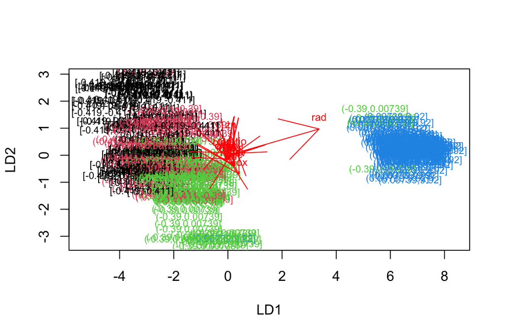

```r
lda.fit<-lda(crime~.,data=train)
lda.arrows <- function(x, myscale = 1, arrow_heads = 0.5, color = "red", tex = 0.75, choices = c(1,2)){
  heads <- coef(x)
  arrows(x0 = 0, y0 = 0,
         x1 = myscale * heads[,choices[1]],
         y1 = myscale * heads[,choices[2]], col=color, length = arrow_heads)
  text(myscale * heads[,choices], labels = row.names(heads),
       cex = tex, col=color, pos=3)
}
classes <- as.numeric(train$crime)

plot(lda.fit,dimen=2,col=classes,pch=classes)
lda.arrows(lda.fit, myscale = 1)
```

#### Task 6. Remove and predict.

I will take crime variable from test to correct_crime. And remove crime variable from test data.

```r
correct_crime <-test$crime
test <- dplyr::select(test, -crime)
head(test)
```

```
##             zn      indus       chas        nox         rm        age
## 6  -0.48724019 -1.3055857 -0.2723291 -0.8344581  0.2068916 -0.3508100
## 10  0.04872402 -0.4761823 -0.2723291 -0.2648919 -0.3994130  0.6154813
## 13  0.04872402 -0.4761823 -0.2723291 -0.2648919 -0.5630867 -1.0506607
## 25 -0.48724019 -0.4368257 -0.2723291 -0.1440749 -0.5132730  0.9067897
## 34 -0.48724019 -0.4368257 -0.2723291 -0.1440749 -0.8306578  0.9387626
## 37 -0.48724019 -0.7545936 -0.2723291 -0.4806367 -0.6314027 -0.2548913
##             dis        rad        tax    ptratio      black      lstat
## 6   1.076671135 -0.7521778 -1.1050216  0.1129203 0.41016511 -1.0422909
## 10  1.328320207 -0.5224844 -0.5769480 -1.5037485 0.32899954  0.6227277
## 13  0.786365270 -0.5224844 -0.5769480 -1.5037485 0.37051338  0.4280788
## 25  0.287103768 -0.6373311 -0.6006817  1.1753027 0.41246535  0.5106995
## 34 -0.003724486 -0.6373311 -0.6006817  1.1753027 0.02295823  0.7977717
## 37 -0.198100718 -0.5224844 -0.7668172  0.3438730 0.22877484 -0.1740726
##           medv
## 6   0.67055821
## 10 -0.39499459
## 13 -0.09055093
## 25 -0.75380318
## 34 -1.02562788
## 37 -0.27539172
```

Looks OK. Now let’s predict and tabulate.

```r
lda.pred <- predict(lda.fit, newdata =test)
table(correct=correct_crime,predicted=lda.pred$class)
```

```
##                  predicted
## correct           [-0.419,-0.411] (-0.411,-0.39] (-0.39,0.00739] (0.00739,9.92]
##   [-0.419,-0.411]              12              8               2              0
##   (-0.411,-0.39]                7             20               6              0
##   (-0.39,0.00739]               1              6              15              2
##   (0.00739,9.92]                0              0               0             23
```

#### Task 7. Reload and etc.

Reload data and calculate euclidian and manhattan distances.

```r
data("Boston")
sc_data2<-scale(Boston)
dist_eu<-dist(sc_data2)
summary(dist_eu)
```

```
##    Min. 1st Qu.  Median    Mean 3rd Qu.    Max.
##  0.1343  3.4625  4.8241  4.9111  6.1863 14.3970
```

```r
dist_man <- dist(sc_data2, method = 'manhattan')
summary(dist_man)
```

```
##    Min. 1st Qu.  Median    Mean 3rd Qu.    Max.
##  0.2662  8.4832 12.6090 13.5488 17.7568 48.8618
```

**Clustering.**

2 clusters.

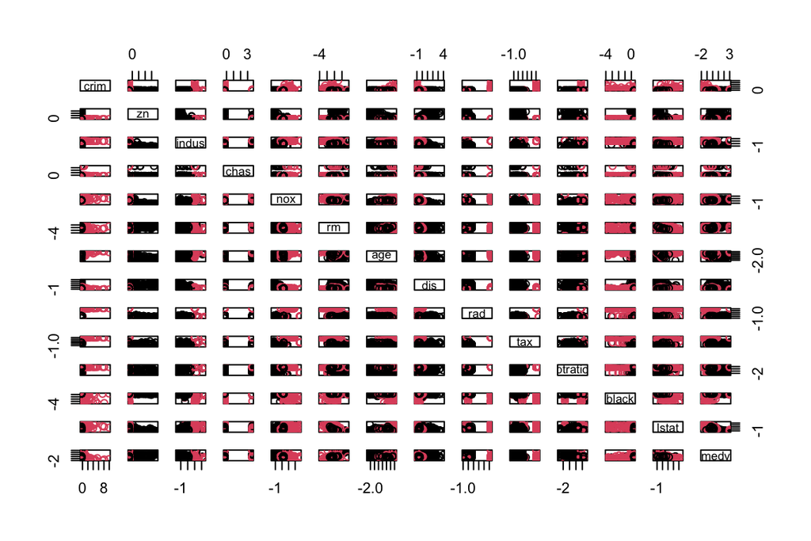

```r
km <-kmeans(sc_data2, centers = 2)
pairs(sc_data2, col = km$cluster)
```

3 clusters.

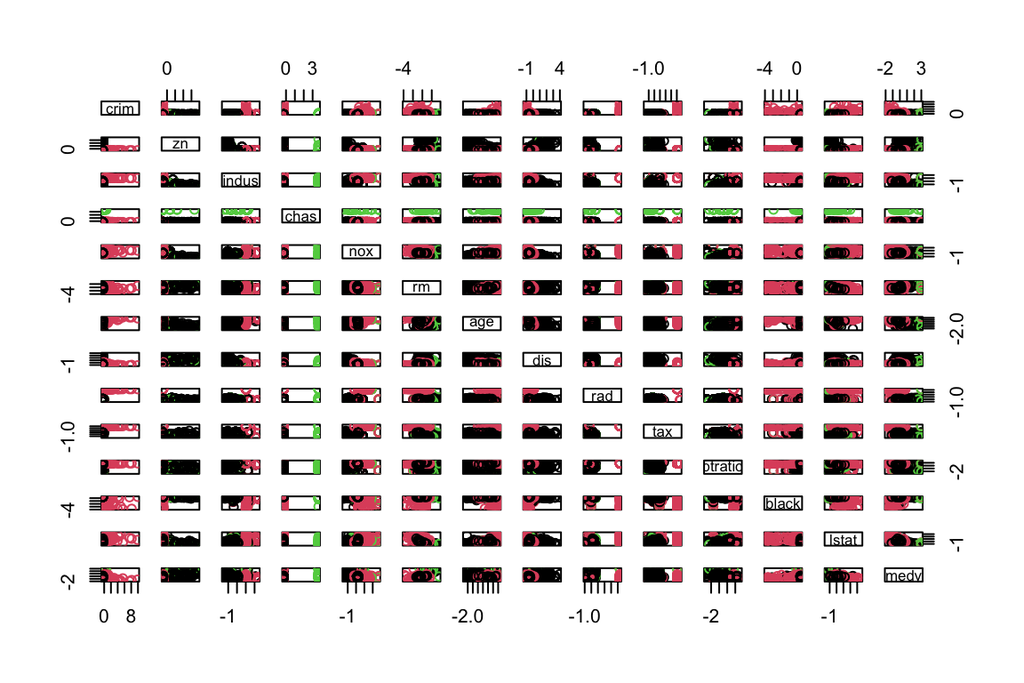

```r
km <-kmeans(sc_data2, centers = 3)
pairs(sc_data2, col = km$cluster)
```

4 clusters.

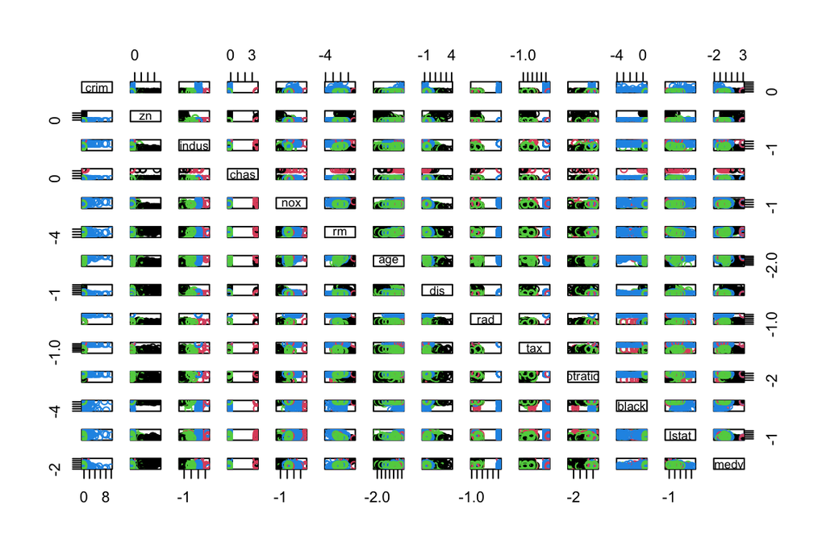

```r
km <-kmeans(sc_data2, centers = 4)
pairs(sc_data2, col = km$cluster)
```

Dear reviewer, if you could see and understand anything on this plots, you warmly welcome to give comments. I honestly could not see or understand presented pairs.

No Bonus.